# Analyze XP_028889033 family evolution and adhesin properties

Bin He

11/01/2020

[output not shown]

## Goal

Analyze the adhesin properties of the XP_028889033 homologs (putative adhesin in *C. auris*) This is version 3 of the analysis, using the updated homologs on 2021-02-05

## Build datasets

```bash
# edit the PYTHON path below to match your local system
~/sw/miniconda3/bin/python extract_seq_info.py
```

Load in the sequence information.

> note that I need to manually edit the sequence ids for four sequences from fungidb, because I used their refseq_id when retrieving their chromosomal locations.

| GRYC ID | Refseq_ID |
| --- | --- |
| CLUG_05233 | XP_002615218.1 |
| CPAR2_600430 | XP_036662815.1 |
| CPAR2_806390 | XP_036665262.1 |
| CPAR2_806420 | XP_036665265.1 |

```r
sps.list <- c("Cduobushaemulonis","Cpseudohaemulonis","Chaemuloni","Cauris","Clusitaniae","Dhansenii","Cparapsilosis","Lelongisporus","Ctropicalis","Cdubliniensis","Calbicans","Sstipitis","Klactis","Ncastellii","Cglabrata","Nbracarensis","Ndelphensis","Nnivariensis")
seqInfo <- read_tsv("data/XP_028889033_homologs.tsv", comment = "#", col_types = "ccci") %>%
  mutate(species_id = factor(species, levels = sps.list), species = NULL)
chrLoc <- read_tsv("data/XP_028889033_homologs_chr_loc.tsv", col_types = cols()) %>%
  mutate(id = ifelse(is.na(accession), gene_id, accession),
         accession = NULL,
         species_id = factor(species_id, levels = sps.list),
         relLoc = round(chrstart/chrL, 3))

seqInfo <- seqInfo %>%
  left_join(chrLoc) %>%
  mutate(assemblystatus = factor(assemblystatus, levels = c("Complete Genome","Chromosome","Contig","Scaffold"),
                                 labels = c("Chromosome", "Chromosome", "Partial", "Partial")),
         species_gr = factor(species_id, labels =
                               c(rep("MDR clade",3),"C. auris","C. lusitaniae","D. hansenii",
                                 rep("parapsilosis clade",2), rep("albicans clade",3),
                                 "S. stipitis", rep("Saccharomycetaceae",6)))) %>%
  select(name, id, source, starts_with("gene"), starts_with("species"), strain, starts_with("assembly"),
         length, n_seqs, starts_with("chr"), relLoc)
```

## Species tree

Below is the relationship between the species studied in this analysis.

```r
sps.tree <- read.tree(file = "data/20200724-species-tree.nwk")
p <- ggtree(sps.tree, ladderize = FALSE) + xlim(0,12) + scale_y_reverse() +
  geom_tiplab(size = 4, align = TRUE, linesize = .5, fontface = 4) +
  geom_cladelabel(node = 22,  label = "Clavispora", offset = 3.7, color = "magenta",
                  offset.text = 0.2, angle = 270, hjust = .5, extend = 0.3) + # Clavispora
  geom_cladelabel(node = 23,  label = "MDR", offset = 4.5, color = "purple", fontface = 2,
                  offset.text = 0.2, angle = 270, hjust = .5, extend = 0.3) + # MDR
  geom_cladelabel(node = 27,  label = "Candida", offset = 2.7, color = "salmon",
                  offset.text = 0.2, angle = 270, hjust = .5, extend = 0.3) + # Candida
  geom_cladelabel(node = 29,  label = "albicans", offset = 3.5, color = "red", fontface = 2,
                  offset.text = 0.2, angle = 270, hjust = .5, extend = 0.3) + # albicans
  geom_cladelabel(node = 31,  label = "Saccharomycetaceae", offset = 2.7, color = "grey20",
                  offset.text = 0.2, angle = 270, hjust = .5, extend = 0.3) # Sacchromycetaceae
```

[output not shown]

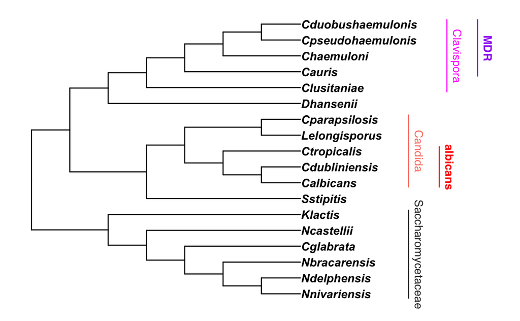

```r
p
```

**Fig. 1 Phylogenetic relationship of the species analyzed in this study.** This species tree is based on the Maximum likelihood phylogeny from Muñoz *et al.* 2018 (PMID: 30559369) for the most part, with the exception of the species in the Saccharomycetaceae family, which is based on Gabaldón *et al.* 2016 (PMID: 27493146).

> Note that he placement of *Debaryomyces hansenii* differs between the above two publications. The former placed it closer to the Clavispora genus while the latter placed it closer to the Candida genus. We based ours on the first publication. Another large scale phylogenetic analysis (Shen *et al.* 2018 (PMID: 30415838)), also placed *D. hansenii* closer to the Candida genus. However, in both studies, which reported bootstrap support values in addition to the phylogeny, the support for the part of the tree involving *D. hansenii* is relatively low suggesting uncertainty in resolving the relationship. We chose to place *D. hansenii* closer to the Clavispora genus because this is more congruent with the gene tree for the Hil family proteins we inferred below.

## Gene tree

### RAxML tree before reconciliation

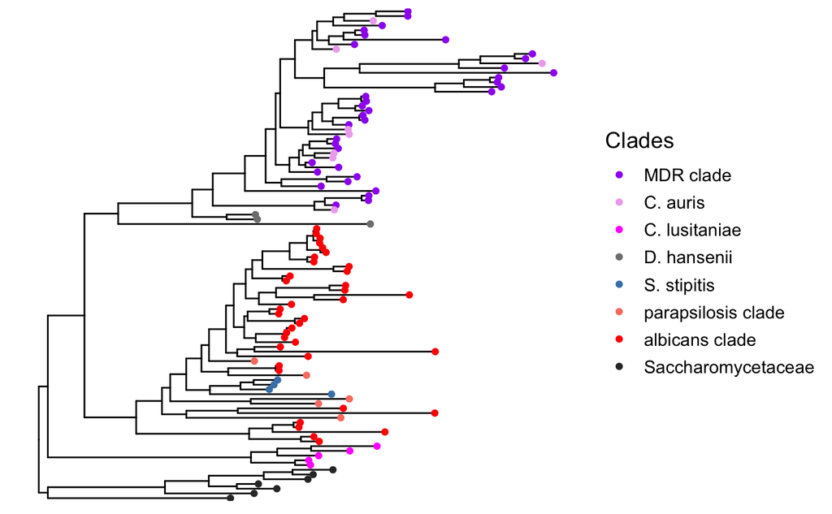

```r
gene.tree <- read.tree("data/RAxML_gene_tree.clustalo_3701250_rooted.nwk")
df <- seqInfo %>% select(label = name, species_id, species_gr)
gene.tree <- full_join(gene.tree, df, by = "label")
ggtree(gene.tree, ladderize = TRUE) +
  #scale_y_reverse() +
  geom_tippoint(aes(color = species_gr)) +
  scale_color_manual(name = "Clades",
                     values = c("MDR clade"   = "purple",
                                "C. auris"    = "plum2",
                                "C. lusitaniae" = "magenta",
                                "D. hansenii" = "gray50",
                                "S. stipitis" = "steelblue",
                                "parapsilosis clade" = "salmon",
                                "albicans clade" = "red",
                                "Saccharomycetaceae" = "grey20")) +
  theme(text = element_text(size = 14))
ggsave("output/img/20210624-raxml-gene-tree-color.png", width = 7, height = 6)
```

**Fig. 2 RAxML inferred gene tree for Hyr/Iff-Like (HIL) family members in Ascomycetes.** The branch length is proportional to the inferred substitions per site. The tree is manually rooted on the Saccharomycetaceae family, which is the outgroup to both the Candida and Clavispora genera and whose Hil homologs form a distinct group. Protein sequence names are not shown for brevity, but are color coded based on the species (groups) they belong to. The clade color code is nested such that if a sequence belongs to both a species and a clade, e.g. *C. auris* and the MDR clade, the sequence will be colored based on the smaller phylogenetic unit, i.e. *C. auris*.

### Gene tree after reconciliation

We reconciled the gene tree with the species tree in Notung 2.9. The purpose of this step is to reconstruct the history of gene duplications and losses (transfers don’t apply to this case) and to rearrange weakly supported parts of the gene tree to reduce the total event score in accordance with the evolutionary parsimony principal.

Briefly, after both the gene tree and the rooted species tree (see above) were loaded into the graphic user interface, the rooting analysis was run and the branch receiving the highest root score was the same as the manually chosen branch as shown in Fig. 2, namely the ancestral branch for all the Saccharomycetaceae proteins. After rooting and reconciliation, a total of 59 duplications and 47 losses were inferred. The reconciled gene tree was then rearranged. In this step, weakly supported branches – those with rapid bootstrap score < 90% – were allowed to be swapped and the event score, calculated as a weighted sum of the total loss and duplication events, was calculated for each rearrangement. Among all rearranged gene tree topologies, the one with the lowest event score had 42 duplications and 12 losses. This is the gene tree that is shown below.

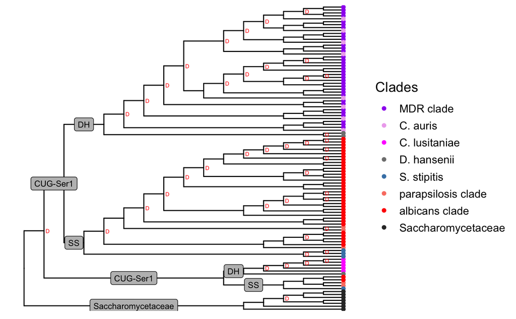

```r
gene.tree.rec <- read.nhx(file = "output/notung/RAxML_bipartitions.clustalo_3701250_rearranged90.nhx")
gene.tree.rec <- full_join(gene.tree.rec, df, by = "label")
ggtree(gene.tree.rec, ladderize = TRUE, branch.length = "none") +
  geom_label(aes(x = branch, label =  ifelse(S %in% c("Saccharomycetaceae", "CUG-Ser1", "DH", "SS") & node != 106, S, NA)),  fill = "gray", size = 3) +
  geom_text(aes(label = ifelse(D == "Y", "D", NA)), hjust = -0.4, size = 2, color = "red") +
  geom_tippoint(aes(color = species_gr)) +
  scale_color_manual(name = "Clades",
                     values = c("MDR clade" = "purple", "C. auris" = "plum2",
                                "C. lusitaniae" = "magenta", "D. hansenii"  = "gray50",
                                "S. stipitis" = "steelblue", "parapsilosis clade" = "salmon",
                                "albicans clade" = "red",  "Saccharomycetaceae" = "grey20")) +
  theme(text = element_text(size = 14))
ggsave("output/img/20210624-reconciled-rearranged90-gene-tree-color.png", width = 9, height = 7)
```

**Fig. 3 Reconciled and rearranged gene tree for Hyr/Iff-Like (HIL) family members in Ascomycetes.** The cladogram shows only the topology of the tree, with endpoints colored in the same way as in Fig. 2. A red “D” next to an internal node indicates an inferred gene duplication event at that node. The labels with gray background highlight the main features of the tree: 1) the Saccharomycetaceae sequences form the outgroup, suggesting there was no ancient duplication prior to the divergence of the family and the remaining species; 2) the CUG-Ser1 clade, which contains both the Candida and Clavispora genera, forms two duplicate groups, suggesting an early duplication event in the clade; 3) the top CUG-Ser1 branch further experienced extensive duplications *independently* in the Clavispora genus, labeled by the outgroup *D. hansenii* (DH), and the Candida genus, labeled by the outgroup *S. stipitis* (SS).

### Gains and losses on species tree

```
Warning: Removed 29 rows containing missing values (geom_label).
```

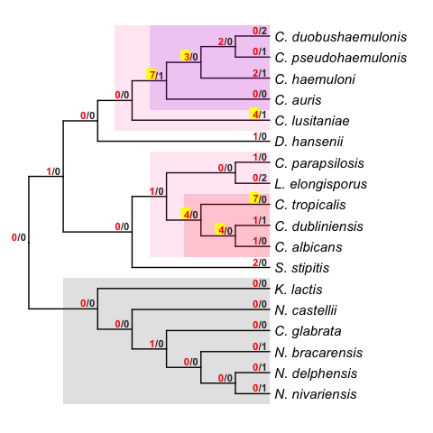

```r
# read in notung parsed event summary stats
notung.stat <- read_tsv("output/notung/RAxML_bipartitions.clustalo_3701250_notung_event_summary.txt", col_types = 'cii')
sps.tree %>%
  full_join(notung.stat, by = "label") %>%
  as_tibble() %>%
  mutate(label = paste0(str_sub(label, 1, 1), ". ", str_sub(label, 2))) %>%
  as.treedata() %>%
  ggtree(ladderize = FALSE) + scale_y_reverse() +
  geom_tiplab(size = 4, fontface = "italic", offset = 0.1) + xlim(0,11) +
  geom_hilight(node = 22, fill = "hotpink", alpha = 0.15) + # Clavispora
  geom_hilight(node = 23, fill = "purple", alpha = 0.15)  + # MDR
  geom_hilight(node = 27, fill = "hotpink", alpha = 0.15) + # Candida
  geom_hilight(node = 29, fill = "red", alpha = 0.15)     + # albicans
  geom_hilight(node = 31, fill = "grey20", alpha = 0.15)  + # Sacchromycetaceae
  geom_text(aes(label = duplications), hjust = 3, vjust = -.3,
            size = 3, color = "red", fontface = 2) +
  geom_text(aes(label = paste0("/", losses)), hjust = 1.3, vjust = -.3,
            size = 3, color = "grey20", fontface = 2) +
  geom_label(aes(label = ifelse(duplications >= 3, duplications, NA)), hjust = 2.1,
             vjust = -.11, size = 3, color = "red", fill = "yellow1", fontface = 2,
             label.size = 0, label.padding = unit(0.12, "lines"))
```

```r
ggsave("output/img/20210622-species-tree-with-gains-losses.png", width = 5, height = 5)
```

**Fig. 4 Inferred gene duplications and losses in the Hyr/Iff-Like (HIL) family in Ascomycetes.** The cladogram shows the species relationship with shadings as in Figure 1. The numbers on top of each branch are the inferred duplications (red) and losses (black) using Notung 2.9. Yellow highlight emphasize the branches that experience three or more duplications.

```r
p.tree <- sps.tree %>% as_tibble() %>%
  mutate(label = paste0(str_sub(label, 1, 1), ". ", str_sub(label, 2))) %>%
  as.treedata() %>% ggtree(ladderize = FALSE) + xlim(0,14) + scale_y_reverse() +
  geom_tiplab(size = 4, align = TRUE, linesize = .5, fontface = "italic", offset = 0.1) +
  geom_hilight(node = 22, fill = "hotpink", alpha = 0.2) + # Clavispora
  geom_hilight(node = 23, fill = "purple", alpha = 0.2)  + # MDR
  geom_hilight(node = 27, fill = "hotpink", alpha = 0.2) + # Candida
  geom_hilight(node = 29, fill = "red", alpha = 0.2)     + # albicans
  geom_hilight(node = 31, fill = "grey20", alpha = 0.2)    # Sacchromycetaceae
```

[output not shown]

```r
ggsave("output/img/20210624-species-tree-side.png", p.tree, width = 4, height = 6)
```

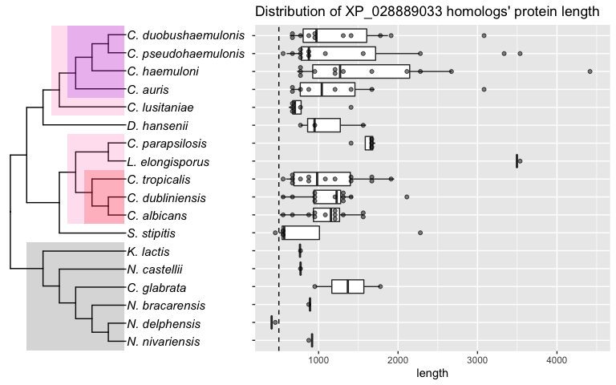

```r
# plot the length distribution of the homologs in each species
p <- ggplot(seqInfo, aes(x = reorder(species_id, desc(species_id)), y = length)) +
  geom_boxplot(outlier.shape = NA) + geom_hline(yintercept = 500, linetype = 2) +
  geom_dotplot(binwidth = 100, binaxis = "y", stackdir = "center", dotsize = 0.5,
               binpositions = "all", fill = rgb(0,0,0,0.5), color = rgb(0,0,0,0.6)) +
  coord_flip() +
  labs(title = "Distribution of XP_028889033 homologs' protein length") +
  theme(axis.title.y = element_blank(), axis.text.y = element_blank())

plot_grid(p.tree, p, align = "h", ncol = 2, rel_widths = c(1,1.5), scale = c(1.08,1))
```

**Fig. 5 Distribution of Hil family homologs’ length across species.** The shadings in the species tree on the left is the same as in Figure 1. Protein lengths are plotted both as a dotplot (binned in 100 a.a. bins) and a boxplot, where the box represents the interquartile range, the middle bar indicates the median and the whisker 1.5 times the interquartile range.

## Chromosomal locations

```r
p <- seqInfo %>%
  mutate(chr = paste(species_id, chraccver, sep = "_")) %>%
  ggplot(aes(x = chr)) +
  geom_segment(aes(xend = chr, y = 1, yend = chrL, color = assemblystatus), size = 2) +
  geom_segment(aes(xend = chr, y = chrstart, yend = chrstart+7000), color = "red", size = 3)
p + coord_flip() + theme_classic() + scale_color_manual(values = c("grey50", "grey")) +
  theme(axis.text.y = element_text(size = 5),
        axis.line.y = element_blank(), axis.ticks.y = element_blank(),
        axis.line.x = element_blank(), axis.ticks.x = element_blank(),
        legend.position = c(0.85,0.85),
        panel.background = element_rect(fill = alpha("lightblue",0.5))) +
  labs(y = "Position on chromosome or scaffold", x = "Chromosomes / Scaffolds", color = "Assembly Status") +
  ggtitle("Chromosomal locations of XP_028889033 homologs")
ggsave("output/img/20210213-homologs-chr-loc.png", bg = "transparent", width = 6, height = 5)
```

```r
p <- seqInfo %>% filter(!(chrL < 1e6 & assemblystatus == "Partial")) %>%
  mutate(dTip = ifelse(relLoc < 0.5, relLoc, 1-relLoc)) %>%
  ggplot(aes(x = dTip)) + facet_wrap(~assemblystatus) +
  xlab("Distance from Chromosome or Scaffold Ends") + labs(fill = "Species group") +
  scale_x_continuous(breaks = seq(0,0.5,by = 0.1))
p + geom_histogram(binwidth = 0.05)
ggsave("output/img/20210213-distribution-on-chromosome-or-scaffolds-histogram-grey.png", width = 5, height = 3)
p + geom_histogram(aes(fill = species_gr), binwidth = 0.05) + scale_fill_brewer(palette = "Paired")
ggsave("output/img/20210213-distribution-on-chromosome-or-scaffolds-histogram.png", width = 6, height = 3)
```

### Are members of this protein family enriched in the subtelomeric regions?

To formally test this hypothesis, I need to account for the background gene density differences along the chromosomes. The idea is to compare the chromosomal positions for this group of proteins compared with the gene densities on the chromosomes they reside on. We will restrict our analysis to those genomes with a chromosomal level assembly status for obvious reasons.

> **Update 2021-06-21** We will also include C. auris B11221 as we know its assembly is nearly at the chromosomal level

```r
use.sps <- seqInfo %>%
  filter(assemblystatus == "Chromosome" | species_id == "Cauris") %>%
  select(species_id, assembly) %>% unique()
use.sps
# now let's also create a new tibble for our homologs from these species
fg.freq <- chrLoc %>%
  filter(species_id %in% use.sps$species_id) %>%
  # remove the one C. auris gene located on an unassembled fragment
  filter(!(species_id == "Cauris" & chr_name == "scaffold00015")) %>%
  # change the scaffold name to chromosome name (they correspond)
  mutate(chr_name = gsub("scaffold0+", "", chr_name))
```

To conduct this test, we first need to prepare and compute the background gene densities. To do this, we will gather the genome assembly files for the selected species, read them into R, and generate a table that contains one row for each gene, with its gene ID, chromosome number, chromosome length and the start position expressed as a percentage measured from the chromosome ends.

```r
# 1. prepare file names
#   get all file names that ends with "feature_table.txt.gz", which contain the gene annotation
feature.files <- list.files(path = "data/assembly-info/", pattern = "*feature_table.txt.gz$")
names(feature.files) <- sapply(str_split(feature.files, pattern = "_"), function(x) {
  paste(x[1], x[2], sep = "_")
})
#   get all file names that ends with "assembly_report.txt", which contain the chromosomal length
assembly.files <- list.files(path = "data/assembly-info/", pattern = "*assembly_report.txt$")
names(assembly.files) <- sapply(str_split(assembly.files, pattern = "_"), function(x) {
  paste(x[1], x[2], sep = "_")
})
use.sps$FeatureFile <- feature.files[use.sps$assembly]
use.sps$AssemblyFile <- assembly.files[use.sps$assembly]

# 2. read in the assembly information
feature.col.names <- c("feature","class","assembly","assembly_unit","seq_type","chromosome","genomic_accession","start","end","strand","product_accession","non_redundant_refseq","related_accession","name","symbol","GeneID","locus_tag","feature_interval_length","product_length","attributes")
assembly.col.names <- c("chromosome","seq_role","assign_molecule","type","gb_acc","relationship",
                        "chraccver","assembly_unit","seqL","ucsc_name")
compute.bg.freq <- function(row){
  assembly.file <- row["AssemblyFile"]
  assembly <- read_tsv(paste0("data/assembly-info/",assembly.file), comment = "#",
                       col_names = assembly.col.names, col_types = "ccccccccic")
  feature.file <- row["FeatureFile"]
  feature <- read_tsv(paste0("data/assembly-info/",feature.file), col_names = feature.col.names,
                      col_types = "ccccccciicccccccciic", skip = 1)
  res <- feature %>%
    filter(feature == "mRNA") %>%
    # these feature tables are organized hierarchically, with the top level being "gene"
    # the next level one of "mRNA", "ncRNA", "tRNA" or "rRNA". we only count protein-coding genes, i.e.
    # "mRNA". the reason I didn't select the "CDS" feature type is because in a small number of cases,
    # one mRNA feature contains more than one CDS feature, possibly due to splicing or alternative
    # translational start site
    select(chromosome, start, end) %>%
    left_join(select(assembly, chromosome, chraccver, seqL), by = c("chromosome" = "chromosome")) %>%
    mutate(relLoc = round(start / seqL, 3))
  return(res)
}
# apply the function to the genomes, but leave out C. auris
bg.freq <- apply(filter(use.sps, species_id != "Cauris"), MARGIN = 1, compute.bg.freq)
names(bg.freq) <- use.sps %>% filter(species_id != "Cauris") %>% pull(species_id)
```

Separately calculate the background frequency for *C. auris*

```r
compute.bg.freq.cau <- function(){
  assembly.col.names <- c("chromosome","seq_role","assign_molecule","type","gb_acc","relationship",
                        "chraccver","assembly_unit","seqL","ucsc_name")
  row = use.sps %>% filter(species_id == "Cauris") # C. auris entry
  assembly.file <- row["AssemblyFile"]
  assembly <- read_tsv(paste0("data/assembly-info/",assembly.file), comment = "#",
                       col_names = assembly.col.names, col_types = "ccccccccic") %>%
    filter(as.integer(str_sub(chromosome, -2, -1)) <= 7)
  feature.file <- row["FeatureFile"]
  feature <- read_tsv(paste0("data/assembly-info/",feature.file), col_names = feature.col.names,
                      col_types = "ccccccciicccccccciic", skip = 1)
  res <- feature %>%
    filter(feature == "mRNA") %>%
    select(chraccver = genomic_accession, start, end) %>%
    right_join(select(assembly, chromosome, chraccver, seqL), by = "chraccver") %>%
    mutate(relLoc = round(start / seqL, 3),
           chromosome = gsub("scaffold0+","",chromosome))
  return(res)
}
bg.freq$Cauris <- compute.bg.freq.cau()
```

```r
bg.freq$Dhansenii %>% ggplot(aes(x = relLoc)) +
  geom_density() + facet_wrap(~ chromosome) + ggtitle("D. hansenii") + theme(plot.title = element_text(hjust = 0.5))
```

```r
bg.freq$Dhansenii %>% ggplot(aes(x = relLoc)) +
  geom_histogram(breaks = seq(0,1,0.05)) +
  facet_wrap(~ chromosome) + ggtitle("D. hansenii") + theme(plot.title = element_text(hjust = 0.5))
ggsave("output/img/20210303-dhansenii-chromosome-gene-density-histogram.png", width = 6, height = 4)
```

In order to compare the distribution of *all* genes in different bins of the chromosomes to the homologs in our case study, we can divide each chromosome in the `nrow(use.sps)` genomes into an arbitrary number of bins after “folding” them in half, e.g. 0-10%, 10-20%, 20-30%, 30-40% and 40-50%. To be able to visually compare the distribution of our homologs and the genome background, we will create a special “chromosome” class that will be our homologs and combine them with the `bg.freq` table.

```r
freq.bins <- c(-0.001, seq(0.1, 0.5, 0.1)); freq.binsL <- c(0, freq.bins[-1])
freq.label <- paste0(head(freq.binsL, -1)*100,"-",tail(freq.binsL, -1)*100,"%")
bg.freq.tb <- bind_rows(bg.freq, .id = "species") %>%
  mutate(fold.relLoc = ifelse(relLoc <= 0.5, relLoc, 1-relLoc),
         bin = cut(fold.relLoc, breaks = freq.bins, labels = freq.label))

# add the homologs
fg.freq <- fg.freq %>%
  mutate(fold.relLoc = ifelse(relLoc <= 0.5, relLoc, 1-relLoc),
         bin = cut(fold.relLoc, breaks = freq.bins, labels = freq.label))
freq.plot <- fg.freq %>%
  mutate(chromosome = "X") %>%  # we label the homologs as X to make it a separate class
  select(species = species_id, chromosome, bin) %>%
  bind_rows(select(bg.freq.tb, species, chromosome, bin))
# plot
freq.plot %>%
  mutate(species = paste0(substr(species, 1, 1), ". ", substr(species, 2, 15))) %>%
  ggplot(aes(x = chromosome, group = bin, fill = bin)) + geom_bar(position = position_fill()) +
  facet_wrap(~ species, scales = "free_x") + scale_fill_brewer(type = "qual", palette = 3) +
  scale_y_continuous(name = "Proportion", trans = "reverse") + theme_cowplot() + panel_border()

ggsave("output/img/20210303-compare-homologs-chromosomal-locations-to-bg.png", width = 8, height = 6)
```

Now that we have the background gene frequencies computed, we can start constructing a test that tests for significant departure in the chromosomal locations of our protein family from the background frequencies. One idea is to divide the chromosome into equal-sized bins and use the frequencies of *all* genes in each bin as the multinomial probabilities in the null hypothesis. If our proteins were randomly selected from each chromosome without regard to their location, we would expect their locations to conform to the background frequencies. This can be tested using an exact multinomial test or an approximate Chi-square test or G-test. Since we don’t distinguish the two ends of a chromosome, we can “fold” the chromosome “in half” and measure each gene’s location as a percentage from the closer end, i.e. the relative location ranging from 0%-50%. If we can reject the null hypothesis, that constitutes evidence that the proteins from our group are not randomly selected from the background set.

**Result of multinomial test**

```r
# install XNomial package for the multinomial exact test function
# https://cran.r-project.org/web/packages/XNomial/vignettes/XNomial.html#e1
while(!require(XNomial))
  suppressMessages(install.packages("XNomial"))
# calculate pooled background frequency
bg.cnt <- cut(bg.freq.tb$fold.relLoc, breaks = freq.bins, labels = freq.label) %>% tabulate()
fg.cnt <- tabulate(fg.freq$bin)
xmulti(obs = fg.cnt, expr = bg.cnt, detail = 3)
```

[output not shown]

The test above assumes that the gene density along all chromosomes in the seven species follow the same distribution. The empirical observation supports that hypothesis. Should that to be not the case, we could also account for the variability in gene density distribution between species or even between chromosomes within a species. The idea is to first collect the chromosomes that our homologs come from, and then randomly sample the **same** number of genes as the number of our homologs on that chromosome. Do this for all of the homolog-containing chromosomes, we would obtain one random sample. Repeat this process 1000 times or more, we will then get the pseudosample, which we can use to compare with our observations. Here we need to come up with a statistic that summarizes each of our observation or pseudosample. For example, we could calculate the median % location for each sample, and ask where our observation lie relative to the pseudosamples. I’ll skip this approach for now since the first appraoch appears to be OK given the similar gene density distribution across chromosomes and species.

## Adhesin predictions

### SVM based predictions

[FungalRV](http://fungalrv.igib.res.in/) and [FaaPred](http://bioinfo.icgeb.res.in/faap/) are two Support Vector Machine (SVM) based prediction algorithms that use sequence features such as amino acid composition (frequency, physiochemical properties etc.) as input and train Machine Learning models to distinguish fungal adhesins from non-adhesins.

```r
frv.th = 0.511 # recommended FungalRV score threshold
frv <- read_tsv("output/FungalRV/fungalRV_result.txt", skip = 3, col_names = c("name","frv.score"), col_types = "cd") %>%
  mutate(name = str_sub(name, 2), frv.pred = frv.score > frv.th)
faa <- read_tsv("output/web-download/faapred_result.txt", col_names = c("name","faa.score","faa.pred"), col_types = "cdc") %>%
  mutate(faa.pred = ifelse(faa.pred == "Adhesin", TRUE, FALSE))
if("frv.score" %in% names(seqInfo))
  seqInfo <- select(seqInfo, -frv.score, -frv.pred, -faa.score, -faa.pred)
seqInfo <- seqInfo %>% left_join(frv) %>% left_join(faa)
```

```r
df <- seqInfo %>%
  group_by(species_id) %>%
  summarize(n = n(),
            fungalRV = sum(frv.score > 0.511), faapred = sum(faa.pred, na.rm = T),
            both = sum(frv.score > 0.511 & faa.pred),
            mean.frv = round(mean(frv.score), 2), mean.faa = round(mean(faa.score, na.rm = T), 2))

dt <- DT::datatable(df, options = list(dom = 't', pageLength = 20, ordering = FALSE),
                caption = "Summary of Adhesin Prediction Results")
# the following code is from https://www.r-bloggers.com/2020/05/mimic-excels-conditional-formatting-in-r-2/
brks <- stats::quantile(x <- df[[2]], probs = seq(.05, .95, .05), na.rm = TRUE)
#clrs <- colorRampPalette(c("#fcdbdb", "#ff1515"))(length(brks)+1)
clrs <- colorRampPalette(brewer.pal(n = 4, name = "Reds"))(length(brks)+1)
for (j in 2:5){
  # Create breaks for shading column values high to low
  # Create shades of green for backgrounds
  # Format cells in j-th column
  dt <- DT::formatStyle(dt, j, backgroundColor = DT::styleInterval(brks, clrs))
}
dt
```

|  | species_id | n | fungalRV | faapred | both | mean.frv | mean.faa |
| --- | --- | --- | --- | --- | --- | --- | --- |
| 1 | Cduobushaemulonis | 11 | 10 | 10 | 9 | 1.41 | 0.26 |
| 2 | Cpseudohaemulonis | 12 | 11 | 11 | 10 | 1.37 | 0.28 |
| 3 | Chaemuloni | 12 | 12 | 11 | 11 | 1.59 | 0.31 |
| 4 | Cauris | 8 | 8 | 5 | 5 | 1.49 | -0.38 |
| 5 | Clusitaniae | 5 | 5 | 3 | 3 | 0.81 | -0.64 |
| 6 | Dhansenii | 3 | 2 | 1 | 1 | 0.91 | -0.66 |
| 7 | Cparapsilosis | 4 | 4 | 4 | 4 | 1.18 | 0.11 |
| 8 | Lelongisporus | 1 | 1 | 1 | 1 | 1.28 | 0.44 |
| 9 | Ctropicalis | 14 | 12 | 10 | 9 | 0.93 | -0.29 |
| 10 | Cdubliniensis | 11 | 7 | 10 | 7 | 0.96 | 0.08 |

[output cut: 8 more lines]

```r
# see https://yulab-smu.top/treedata-book/chapter7.html#attach-operator
# the attach operator "%<+%" works on ggtree objects and requires the first column
# of the data frame to contain the tip labels
```

### GPI-anchor prediction

GPI-anchored proteins are characterized by an N-terminal signal peptide, which would direct the protein to the secretary pathway, and a C-terminal GPI-anchor peptide, which would be cleaved and replaced by the GPI-anchor, allowing the protein to be tethered to the cell wall.

For signal peptide, I used SignalP server. Its latest version is 5.0. But I also ran the sequences through their 4.1 version, with two settings. The results of the latter two are almost identical, except for one sequence “XP_024711350.1”, which is only included in the sensitive version, and has a probability lower than 0.5.

```r
# Signal peptide
gff.names <- c("id", "source", "name", "start", "end", "prob", "na1", "na2", "na3")
signalp5 <- read_tsv("output/web-download/signalp_5.0.gff", comment = "#", col_names = gff.names, col_types = "ccciidccc")

if("signalp" %in% names(seqInfo))
  seqInfo <- select(seqInfo, -signalp)

seqInfo <- left_join(seqInfo, select(signalp5, name = id, prob), by = c("name" = "name")) %>%
  mutate(signalp = !is.na(prob)) %>% select(-prob)
```

For GPI-anchor prediction, I used the [PredGPI server](http://gpcr.biocomp.unibo.it/predgpi/).

```r
tmp <- read_delim("output/web-download/predgpi_result.txt", delim = "|", col_names = c("name","fp","omega"))
pred.gpi <- tmp %>%
  mutate(name = str_sub(name,2,-2), # remove > and the trailing space
         fp = as.numeric(str_sub(fp, 9, -2)), # extract the numeric part
         is.gpi = fp <= 0.01,    # based on the cutoff of the PredGPI server (prob < 99% -> not GPI-anchored)
         omega = str_sub(omega, 8),
         cleaveRes = str_sub(omega, 1, 1),
         cleavePos = as.integer(str_sub(omega, 3))
         ) %>%
  left_join(select(seqInfo, name, length), by = c("name" = "name"))

# remove the column if it already exists
if("pred.gpi" %in% names(seqInfo))
  seqInfo <- select(seqInfo, -pred.gpi)
seqInfo <- left_join(seqInfo, select(pred.gpi, name, pred.gpi = is.gpi), by = c("name"="name"))
```

```r
df1 <- seqInfo %>%
  group_by(species_id) %>%
  summarize(SignalP = sum(signalp), GPI_Pred = sum(pred.gpi), Pass = sum(frv.score > 0.511 & signalp & pred.gpi)) %>%
  right_join(df) %>%
  select(species = species_id, Total = n, Pass, FungalRV = fungalRV, SignalP, GPI_Pred)
dt1 <- DT::datatable(df1,
                     options = list(dom = 't', pageLength = 20, ordering = FALSE,
                                    autowidth = TRUE,
                                    # https://rstudio.github.io/DT/options.html
                                    columnDefs = list(list(width = "150", targets = 1),
                                                      list(width = '50', className = "dt-center", targets = 2:6))),
                caption = "Summary of Adhesin Prediction Results")
# the following code is from https://www.r-bloggers.com/2020/05/mimic-excels-conditional-formatting-in-r-2/
brks <- stats::quantile(x <- df1[[2]], probs = seq(.05, .95, .05), na.rm = TRUE)
#clrs <- colorRampPalette(c("#fcdbdb", "#ff1515"))(length(brks)+1)
clrs <- colorRampPalette(brewer.pal(n = 4, name = "Reds"))(length(brks)+1)
for (j in 2:8){
  # Create breaks for shading column values high to low
  # Create shades of green for backgrounds
  # Format cells in j-th column
  dt1 <- DT::formatStyle(dt1, j, backgroundColor = DT::styleInterval(brks, clrs))
}
dt1
```

|  | species | Total | Pass | FungalRV | SignalP | GPI_Pred |
| --- | --- | --- | --- | --- | --- | --- |
| 1 | Cduobushaemulonis | 11 | 10 | 10 | 11 | 11 |
| 2 | Cpseudohaemulonis | 12 | 10 | 11 | 11 | 12 |
| 3 | Chaemuloni | 12 | 9 | 12 | 9 | 12 |
| 4 | Cauris | 8 | 8 | 8 | 8 | 8 |
| 5 | Clusitaniae | 5 | 3 | 5 | 5 | 3 |
| 6 | Dhansenii | 3 | 2 | 2 | 3 | 3 |
| 7 | Cparapsilosis | 4 | 3 | 4 | 4 | 3 |
| 8 | Lelongisporus | 1 | 1 | 1 | 1 | 1 |
| 9 | Ctropicalis | 14 | 7 | 12 | 11 | 9 |
| 10 | Cdubliniensis | 11 | 7 | 7 | 11 | 10 |

[output cut: 8 more lines]

**Summary**

- Most of the Hil homologs in Ascomycetes passed both the GPI-anchor predictions and also the FungalRV predictor, suggesting that they are likely to be cell wall proteins and may play an adhesin function (FaaPred predicted fewer adhesins, but the overall pattern doesn’t change).

```r
# saving the table output to a png file
# https://stackoverflow.com/questions/60287652/how-to-save-a-table-i-created-with-dt-datatable-into-a-high-quality-image
DT::saveWidget(dt1, "output/misc/tmp.html")
webshot::webshot("output/misc/tmp.html", "output/img/20210623-homologs-prediction-summary.png")
```

## Build feature map for homologs

### Tandem repeat structures

The non-NTD portion of the proteins evolve rapidly and many of them contain tandem repeats. Therefore, characterizing and visualizing the type, number and spatial distribution of the tandem repeats serve to highlight the differences in the non-NTD part of the proteins in this family.

To identify and group tandem repeats, I used [XSTREAM](https://amnewmanlab.stanford.edu/xstream) with the following parameters `java -Xmx1000m -Xms1000m -jar ~/sw/XSTREAM/xstream.jar $in -i.7 -I.7 -g3 -e2 -L15 -z -G -O -Asub.txt`. The parameters were chosen to identify degenerate tandem repeats that occur at least two times and must be a minimum length of 5 a.a. or longer and the minimum length of a tandem repeat domain (=period x copy #) must be greater than 15 a.a. Please see `script/xstream.sh` for explanation of the parameters.

```r
tandem <- read_tsv("output/xstream/XSTREAM_XP_028889033_homologs_sub_i0.7_g3_m5_L15_chart.tsv",
                   col_types = "ciiifidcccd", comment = "#") %>%
  rename(name = identifier)
# now let's create a tibble for plotting, which would contain each instance of the tandem repeat on a separate row
tandem.div <- tandem %>%
  rowwise(name) %>%
  summarize(div = list(c(seq(from = start, to = end, by = period), end)), .groups = "drop") %>%
  unnest(div)
```

```r
# summarize stats of tandem repeats
repeats <- tandem %>%
  group_by(type, period) %>%
  summarize(n = n(), copyMean = mean(copyN), .groups = "drop") %>%
  mutate(length = period * copyMean)
```

### Domain diagram

The goal is to produce a cartoon-like plot for each homolog outlining their main features, such as the locations of the PFam domains (mainly the Hyp_reg_CWP), locations of the signal peptide and GPI-anchor, distribution of TANGO sequences. Note that all these features can be represented as a range with associated metadata. So the first step is to collect the coordinates of the features

```r
# GPI-anchor
# use pred.gpi
# Pfam domains
pfam <- read_tsv("output/web-download/HMMER-HMMScan-Pfam-hits.tsv", col_types = "ciiiicciiidddiic")
# save feature file for Jalview examination
# pfam %>% filter(grepl("XP_028889033",seq_id)) %>% select(hmm_name, seq_id, envelope_start, envelope_end) %>% mutate(featuretype = "domain") %>% write_tsv("XP_028889033_features.jalview")
# I manually edited the feature file, so I commented out the line above to avoid accidentally
# overwriting my own edits

# feature set
# structure: id  feature  start  end
feature <- bind_rows(
  seqInfo %>% mutate(type = "entire protein", start = 1) %>% select(name, type, start, end = length),
  pfam %>% select(name = seq_id, type = hmm_name, start = envelope_start, end = envelope_end) %>%
    filter(type == "Hyphal_reg_CWP"),
  # extend the signal peptide segment by 10 amino acids to make it more visible
  signalp5 %>% mutate(type = "SignalP", end = end + 10) %>% select(name = id, type, start = start, end),
  # extend the GPI-anchor C-terminus segment by 20 amino acids to make it more visible
  pred.gpi %>% filter(is.gpi) %>% mutate(type = "GPI-anchor", start = cleavePos-10) %>%
    select(name, type, start, end = length)
) %>% mutate(tip = ifelse(type == "entire protein", as.character(name), as.character(type)))
#feature$type = ordered(feature$type, levels = c("entire protein", "Hyphal_reg_CWP", "SignalP", "GPI-anchor"))
feature.colors <- c("grey", "#1f78b4","#e31a1c", "gray40")

# feature <- bind_rows(
#   seqInfo %>% mutate(type = "entire protein", start = 1) %>% select(id = name, type, start, end = length),
#   pfam %>% select(id = seq_id, type = hmm_name, start = envelope_start, end = envelope_end) %>%
#     filter(type == "Hyphal_reg_CWP"),
#   # extend the signal peptide segment by 10 amino acids to make it more visible
#   signalp5 %>% mutate(type = "SignalP", end = end + 10) %>% select(id, type, start = start, end),
#   # extend the GPI-anchor C-terminus segment by 20 amino acids to make it more visible
#   pred.gpi %>% filter(is.gpi) %>% mutate(type = "GPI-anchor", start = cleavePos-10) %>%
#     select(id = name, type, start, end = length)
# )
# feature$type = ordered(feature$type, levels = c("entire protein", "Hyphal_reg_CWP", "Asp", "Candida_ALS", "Flocculin", "Flocculin_t3", "Hyr1", "PT", "SignalP", "GPI-anchor"))
# feature.colors <- c("grey", "#1f78b4", "#b2df8a", "#33a02c", "#fb9a99", "#fdbf6f", "#ff7f00", "#cab2d6", "#e31a1c", "#6a3d9a")
```

organize the tandem repeats features

```r
tr <- tandem %>%
  left_join(select(repeats, type, copyMean), by = c("type" = "type")) %>%
  mutate(type = ifelse(period * copyMean < 40, "TR-short (<40 aa)", "TR-long (>40 aa)"),
         tip = paste0(consensus_nogap,
                      "\ntype: ", type,
                      "\nperiod: ", period,
                      "\ncopyN: ", copyMean)) %>%
  select(name, type, start, end, tip)
```

Combine domains, SP and GPI-anchor with TR features.

```r
# combine sequence features with tandem repeats
tr.feature <- bind_rows(feature, tr) %>%
  mutate(type = ordered(type, levels = c("entire protein", "Hyphal_reg_CWP", "SignalP", "GPI-anchor", "TR-long (>40 aa)", "TR-short (<40 aa)")))
comb.col <- c(feature.colors, "#a87b00bb", "#ffbb00bb")
```

reorder the sequences by their positions in the gene tree

```r
# in order to plot properties of the sequences in an order that is consistent with the sequences' position in the gene tree
genetreeOrder <- scan("data/reorder_by_gene_tree.txt", what = "character")
```

```
Read 104 items
```

```r
#feature$name <- ordered(feature$name, levels = rev(genetreeOrder))
tr.feature$name <- ordered(tr.feature$name, levels = rev(genetreeOrder))
write_tsv(tr.feature, file = "output/misc/R-feature-table.tsv", col_names = TRUE)
```

```r
p.gtree <- ggtree(gene.tree.rec, ladderize = FALSE, branch.length = "none") +
  scale_y_reverse() +
  geom_label(aes(x = branch, label =  ifelse(S %in% c("Saccharomycetaceae", "CUG-Ser1", "DH", "SS") & node != 106, S, NA)),  fill = "gray", size = 3) +
  geom_tippoint(aes(color = species_gr), show.legend = FALSE) +
  scale_color_manual(name = "Clades",
                     values = c("MDR" = "purple",          "Cauris" = "plum2",
                                "Clusitaniae" = "magenta", "Dhansenii" = "gray50",
                                "Sstipitis" = "steelblue", "parapsilosis" = "salmon",
                                "albicans" = "red",  "Saccharomycetaceae" = "grey20")) +
  theme(text = element_text(size = 14))
```

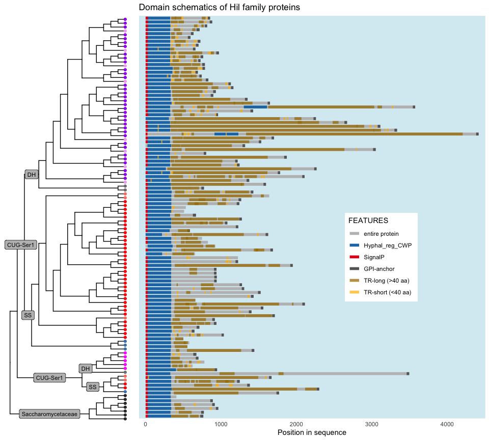

```r
# plot
p1 <- ggplot(tr.feature, aes(x = name, y = start, xend = name, yend = end)) +
  geom_segment(aes(color = type, text = tip), size = 2)
p2 <- geom_segment(data = tandem.div, aes(x = name, xend = name, y = div, yend = div + 1.5), size = 2, color = "white")
p3 <- p1 + coord_flip() + theme_classic() +
  scale_color_manual(values = comb.col) +
  scale_y_continuous(expand = expansion(mult = c(0.02, 0.02))) +
  theme(axis.text.y = element_blank(), axis.title.y = element_blank(),
        axis.line.y = element_blank(), axis.ticks.y = element_blank(),
        axis.line.x = element_blank(), axis.ticks.x = element_blank(),
        legend.position = c(0.7, 0.4),
        panel.background = element_rect(fill = alpha("lightblue",0.5))) +
  labs(title = "Domain schematics of Hil family proteins", y = "Position in sequence", x = "Sequences", color = "FEATURES")
plot_grid(p.gtree, p3, ncol = 2, align = 'v', rel_widths = c(1.5,4), scale = c(1.02,1))
```

```r
ggsave("output/img/20210625-domain-tandem-repeats.png", width = 7, height = 7.5)
```

```r
DT::datatable(
  tandem %>%
    rename(seqL = seqLength, err = consensus_error, seq = consensus_nogap) %>%
    select(-seqAlign, -type, -consensus_gap, -seq, seq) %>%
    arrange(desc(name)),
  fillContainer = FALSE, options = list(pageLength = 10)
)
```

|  | name | seqL | start | end | period | copyN | err | seq |
| --- | --- | --- | --- | --- | --- | --- | --- | --- |
| 1 | XP_722183.2_Calbicans | 919 | 358 | 410 | 27 | 2 | 0.16 | SESSDVVSESSSAIDSLSSSAIESSMK |
| 2 | XP_722183.2_Calbicans | 919 | 406 | 455 | 14 | 3.43 | 0.23 | NSESSSDAGSSSAS |
| 3 | XP_722183.2_Calbicans | 919 | 606 | 801 | 8 | 23.75 | 0.25 | NNGSGSGS |
| 4 | XP_718630.1_Calbicans | 1526 | 539 | 594 | 29 | 2 | 0.21 | SGDTDVSEFSDISLASASDSSGSIADLSI |
| 5 | XP_718630.1_Calbicans | 1526 | 415 | 435 | 12 | 2 | 0.16 | SSSVDFISAPIE |
| 6 | XP_718630.1_Calbicans | 1526 | 857 | 877 | 10 | 2 | 0.14 | FSSDVSESVD |
| 7 | XP_718630.1_Calbicans | 1526 | 784 | 799 | 7 | 2 | 0.25 | SISSIEA |
| 8 | XP_717969.1_Calbicans | 1225 | 542 | 572 | 18 | 2 | 0.19 | TSDLSMNFNTVENFDTLD |
| 9 | XP_717969.1_Calbicans | 1225 | 1081 | 1100 | 10 | 2 | 0.2 | TQEGTQQASR |
| 10 | XP_717969.1_Calbicans | 1225 | 578 | 595 | 9 | 2 | 0.11 | SFDIFETFN |

[output cut: 317 more lines]

## Serine/Threonine content

S/T sites are potential sites for O-glycosylation, which could increase the rididity of the stalk of the protein and allow the N-terminal domain to protrude out of the cell wall facing the exterior. More evidence for the importance of O-glycosylation in a serine/threonine-rich domain can be found [here](https://ec.asm.org/content/10/10/1317.long).

To determine the S/T frequency in the XP_028889033 homologs, I ran the program `freak` from the EMBOSS suite with the parameters of 100 aa sliding window and a step size of 10 aa. After reformating the output, the rest of the analysis is accomplished below.

```r
# load data
ST.freq <- read_tsv("raw-output/ST_freq_100_10_freak.out.gz", col_types = "cid")
S.freq <- read_tsv("raw-output/S_freq_100_10_freak.out.gz", col_types = "cid")
T.freq <- read_tsv("raw-output/T_freq_100_10_freak.out.gz", col_types = "cid")
# convert sequence name column to an ordered list sorted based on the gene tree sequence
ST.freq <- ST.freq %>%  mutate(id = ordered(id, levels = rev(genetreeOrder))) # this will produce the desired order
S.freq <- S.freq %>%  mutate(id = ordered(id, levels = rev(genetreeOrder))) # this will produce the desired order
T.freq <- T.freq %>%  mutate(id = ordered(id, levels = rev(genetreeOrder))) # this will produce the desired order
```

```r
ggplot(ST.freq, aes(x = id, y = pos)) +  geom_tile(aes(fill = freq)) +
  coord_flip() + theme_classic() + scale_fill_distiller(palette = "RdGy", limits = c(0, 0.8), oob = scales::squish, breaks = seq(0, 0.6, by = 0.2)) +
  theme(axis.text.y = element_text(size = 5),
        axis.line.y = element_blank(), axis.ticks.y = element_blank(),
        axis.line.x = element_blank(), axis.ticks.x = element_blank(),
        legend.position = c(0.85,0.35),
        panel.background = element_rect(fill = alpha("lightblue",0.5))) +
  ylim(1, 4500) + labs(y = "Position in sequence", x = "Sequences", color = "Frequency") +
  ggtitle("Serine/Threonine frequency in 100 aa sliding windows")
ggsave("img/20201223-homologs-ST-freq-100aa-window.png", bg = "transparent", width = 7, height = 7)
```

```r
ST.comb <- bind_rows("S/T" = ST.freq, S = S.freq, T = T.freq, .id = "Var") %>%
  mutate(Var = ordered(Var, levels = c("S/T","S","T")))
ggplot(ST.comb, aes(x = id, y = pos)) + geom_tile(aes(fill = freq)) +
  facet_wrap(~Var, scales = "fixed") + theme_minimal() +
  coord_flip() + scale_fill_distiller(palette = "RdGy", limits = c(-0.05, 0.55), oob = scales::squish,
                                      breaks = seq(0,0.5,by=0.1)) +
  #scale_fill_gradient2(low = "#1a1a1a", high = "#b30000", midpoint = 0.2) +
  theme(axis.text.y = element_blank(),
        axis.line.y = element_blank(), axis.ticks.y = element_blank(),
        axis.line.x = element_blank(), axis.ticks.x = element_blank(),
        legend.position = c(0.95,0.24),
        panel.background = element_rect(fill = alpha("lightblue",0.5))) +
  ylim(1, 4500) + ylab("Position in sequence") + xlab("Sequences") +
  ggtitle("Ser/Thr frequency in 100 aa windows (frequency > 0.55 replaced by 0.55)")
ggsave("img/20201223-ST-freq-composite.png", width = 8, height = 4.5)
```

## TANGO prediction of $\beta$-aggregation prone sequences

The amyloid-like $\beta$-aggregation prone sequences have the ability to mediate self-aggregation, which boosts the local concentration of the adhesin molecules on the cell-surface. Similar to the S/T frequency above, we would like to use the output from the prediction algorithm, TANGO, to visulize the distribution of such sequence motifs along the length of the XP_028889033 homolog sequences.

TANGO predictions and the subsequent extraction of $\beta$-aggregation prone sequences were documented in separate Python script, README files and the `tango.Rmd`.

```r
# here we only look at the extracted tango sequences
tango <- read_tsv("tango_summary_table.tsv.gz", col_types = "cciiidddicc")
# reorder the sequences for plotting
tango$name <- ordered(tango$name, levels = rev(genetreeOrder))
# plot
p1 <- ggplot(filter(feature, type == "entire protein"), aes(x = id, y = start)) +
  geom_segment(aes(xend = id, yend = end), size = 2, color = "grey40")
p2 <- geom_segment(data = tango, aes(x = name, xend = name,  y = ifelse(start-4 >= 0, start-4, 0), yend = end + 4, color = median), size = 2)
p3 <- geom_segment(data = filter(feature, type == "Hyphal_reg_CWP"), aes(x = id, y = start, xend = id, yend = end), size = 2, color = "#1f78b4")
p1 + p2 + p3 + coord_flip() + theme_classic() +
  scale_color_distiller(type = "seq", palette = 17, direction = 1) +
  theme(axis.text.y = element_text(size = 5),
        axis.line.y = element_blank(), axis.ticks.y = element_blank(),
        axis.line.x = element_blank(), axis.ticks.x = element_blank(),
        legend.position = c(0.85,0.25),
        panel.background = element_rect(fill = alpha("lightblue",0.5))) +
  ylim(-2, 4500) + labs(y = "Position in sequence", x = "Sequences", color = "Median TANGO score") +
  ggtitle("TANGO hits with Hyphal_reg_CWP domain masked")
ggsave("img/20210110-tango-score-segment.png", width = 7, height = 7)
```